# HW2 part 2 - EDA with R - Group by analysis

Osarodion

2022-01-09

## Step 0 - Familiarize yourself with the data and the problem

In this part of the assignment you’ll do some basic exploratory data analysis with R on a dataset about airline flights out of Detroit Metropolitan Airport. See the README.md file (it’s just a plain text file with markdown in it) for details about the data file.

As we did in class, you’ll be creating an R Markdown document to both prepare a dataset and do some analysis as well as to document the steps you did (and answer some questions I’ll throw at you).

You’ll notice a few “Hacker Extra Credit” tasks thrown in. These are for those of you who want to go a little above and beyond and attempt some more challenging tasks. And, feel free to do a some free form Hacker Extra style work yourself - in other words, do something beyond what was asked. You’ll learn more.

## Step 1 - Create a new R Markdown document

Create a new R Markdown document and name it **hw2_part2_flights_[*your last name*].Rmd**. Mine would be called **hw2_part2_flights_isken.Rmd**. Save it into the same folder as this file.

This will be your working directory.

Create a new R Project based on this working directory.

## Step 2 - Complete the following R tasks

Now you’ll need to complete the following tasks in R. Just like we did in class, you should use a combination of markdown text (be concise, no need to write tons of text) to explain what you are doing and R code chunks to actually do it. When you are done, use the “Knit HTML” button to generate an HTML file from your R Markdown. You’ll be submitting BOTH the completed R Markdown file as well as the generated HTML file.

### Task 1 - Load data and load libraries

You’ll need a few libraries.

```r
library(dplyr)
library(ggplot2)
library(lubridate)
```

Let’s read the data into a `data.frame` named `flights`.

```r
flights <- read.csv("data/ontime_flights_DTW.csv")
```

### Task 2: Use `str` and `summary` to get a quick overview of the dataset

Look at the data types. Check for NAs. Look at the summary stats and note any potential issues with the data.

```r
str(flights)
```

```
## 'data.frame':    12816 obs. of  21 variables:
##  $ ID            : int  55 60 61 67 75 76 165 338 339 340 ...
##  $ Year          : int  2013 2013 2013 2013 2013 2013 2013 2013 2013 2013 ...
##  $ Month         : int  1 1 1 1 1 1 1 1 1 1 ...
##  $ Day           : int  3 2 1 1 3 4 2 3 4 6 ...
##  $ FlightDate    : chr  "1/3/13" "1/2/13" "1/1/13" "1/1/13" ...
##  $ AirlineID     : chr  "9E" "9E" "9E" "9E" ...
##  $ Carrier       : chr  "Endeavor Air Inc." "Endeavor Air Inc." "Endeavor Air Inc." "Endeavor Air Inc." ...
##  $ Origin        : chr  "DTW" "DTW" "DTW" "DTW" ...
##  $ OriginCityName: chr  "Detroit, MI" "Detroit, MI" "Detroit, MI" "Detroit, MI" ...
##  $ OriginState   : chr  "MI" "MI" "MI" "MI" ...
##  $ Destination   : chr  "BUF" "BNA" "DSM" "DCA" ...
##  $ DestCityName  : chr  "Buffalo, NY" "Nashville, TN" "Des Moines, IA" "Washington, DC" ...
##  $ DestState     : chr  "NY" "TN" "IA" "VA" ...
##  $ DepartureTime : int  1022 711 1941 2029 1213 1211 809 1201 1159 1154 ...
##  $ DepartureDelay: int  0 1 1 54 3 1 29 0 -2 -7 ...
##  $ ArrivalTime   : int  1138 814 2020 2138 1414 1400 1020 1216 1214 1211 ...
##  $ ArrivalDelay  : int  -5 6 -19 28 0 -14 33 -13 -15 -18 ...
##  $ Cancelled     : int  0 0 0 0 0 0 0 0 0 0 ...
##  $ ElapsedTime   : int  76 123 99 69 181 169 131 75 75 77 ...
##  $ AirTime       : int  44 84 79 57 157 141 86 48 51 52 ...
##  $ Distance      : int  241 456 534 405 986 986 632 311 311 311 ...
```

```r
summary(flights)
```

```
##        ID              Year          Month        Day         FlightDate
##  Min.   :    55   Min.   :2013   Min.   :1   Min.   : 1.00   Length:12816
##  1st Qu.: 15426   1st Qu.:2013   1st Qu.:1   1st Qu.: 8.00   Class :character
##  Median :116506   Median :2013   Median :1   Median :16.00   Mode  :character
##  Mean   :120314   Mean   :2013   Mean   :1   Mean   :16.06
##  3rd Qu.:177925   3rd Qu.:2013   3rd Qu.:1   3rd Qu.:24.00
##  Max.   :509436   Max.   :2013   Max.   :1   Max.   :31.00
##
##   AirlineID           Carrier             Origin          OriginCityName
##  Length:12816       Length:12816       Length:12816       Length:12816
##  Class :character   Class :character   Class :character   Class :character
##  Mode  :character   Mode  :character   Mode  :character   Mode  :character
##
##
##
##
##  OriginState        Destination        DestCityName        DestState
##  Length:12816       Length:12816       Length:12816       Length:12816
##  Class :character   Class :character   Class :character   Class :character
##  Mode  :character   Mode  :character   Mode  :character   Mode  :character
##
##
##
##
##  DepartureTime  DepartureDelay      ArrivalTime    ArrivalDelay
##  Min.   :   3   Min.   : -20.000   Min.   :   1   Min.   : -72.000
##  1st Qu.:1019   1st Qu.:  -5.000   1st Qu.:1155   1st Qu.: -18.000
##  Median :1418   Median :  -3.000   Median :1546   Median :  -9.000
##  Mean   :1420   Mean   :   7.727   Mean   :1548   Mean   :   1.848
##  3rd Qu.:1751   3rd Qu.:   3.000   3rd Qu.:1932   3rd Qu.:   7.000
##  Max.   :2355   Max.   :1578.000   Max.   :2400   Max.   :1568.000
##  NA's   :200    NA's   :200        NA's   :252    NA's   :282
##    Cancelled        ElapsedTime       AirTime          Distance
##  Min.   :0.00000   Min.   : 26.0   Min.   : 13.00   Min.   :  56.0
##  1st Qu.:0.00000   1st Qu.: 76.0   1st Qu.: 51.00   1st Qu.: 287.0
##  Median :0.00000   Median : 97.0   Median : 70.00   Median : 460.0
##  Mean   :0.01841   Mean   :116.3   Mean   : 88.56   Mean   : 578.3
##  3rd Qu.:0.00000   3rd Qu.:135.0   3rd Qu.:101.00   3rd Qu.: 632.0
##  Max.   :1.00000   Max.   :399.0   Max.   :315.00   Max.   :2079.0
##                    NA's   :282     NA's   :282
```

**QUESTION** What datatype did the `FlightDate` field take on?

> Character data type

**QUESTION** Just from looking at the output of the `summary()` command, what percentage of the flights were cancelled?

> 0.01841 or 1.841%

It looks like most of the numeric fields have 200-300 NAs. However, as you might have already guessed, this is primarily due to the cancelled flights. So, get rid of all the rows in which cancelled is equal to 1. Use `summary` after doing this to confirm that the rows are gone (or use some other method to confirm that you’ve gotten rid of the cancelled flights).

```r
flights_actual <- filter(flights, Cancelled == 0)
flights <- flights_actual
summary(flights)
```

```
##        ID              Year          Month        Day         FlightDate
##  Min.   :    55   Min.   :2013   Min.   :1   Min.   : 1.00   Length:12580
##  1st Qu.: 15879   1st Qu.:2013   1st Qu.:1   1st Qu.: 8.00   Class :character
##  Median :117164   Median :2013   Median :1   Median :16.00   Mode  :character
##  Mean   :121184   Mean   :2013   Mean   :1   Mean   :15.95
##  3rd Qu.:178204   3rd Qu.:2013   3rd Qu.:1   3rd Qu.:24.00
##  Max.   :509436   Max.   :2013   Max.   :1   Max.   :31.00
##
##   AirlineID           Carrier             Origin          OriginCityName
##  Length:12580       Length:12580       Length:12580       Length:12580
##  Class :character   Class :character   Class :character   Class :character
##  Mode  :character   Mode  :character   Mode  :character   Mode  :character
##
##
##
##
##  OriginState        Destination        DestCityName        DestState
##  Length:12580       Length:12580       Length:12580       Length:12580
##  Class :character   Class :character   Class :character   Class :character
##  Mode  :character   Mode  :character   Mode  :character   Mode  :character
##
##
##
##
##  DepartureTime  DepartureDelay      ArrivalTime    ArrivalDelay
##  Min.   :   3   Min.   : -20.000   Min.   :   1   Min.   : -72.000
##  1st Qu.:1019   1st Qu.:  -5.000   1st Qu.:1155   1st Qu.: -18.000
##  Median :1418   Median :  -3.000   Median :1546   Median :  -9.000
##  Mean   :1419   Mean   :   7.678   Mean   :1548   Mean   :   1.848
##  3rd Qu.:1750   3rd Qu.:   3.000   3rd Qu.:1932   3rd Qu.:   7.000
##  Max.   :2355   Max.   :1578.000   Max.   :2400   Max.   :1568.000
##                                    NA's   :16     NA's   :46
##    Cancelled  ElapsedTime       AirTime          Distance
##  Min.   :0   Min.   : 26.0   Min.   : 13.00   Min.   :  56.0
##  1st Qu.:0   1st Qu.: 76.0   1st Qu.: 51.00   1st Qu.: 287.0
##  Median :0   Median : 97.0   Median : 70.00   Median : 460.0
##  Mean   :0   Mean   :116.3   Mean   : 88.56   Mean   : 581.9
##  3rd Qu.:0   3rd Qu.:135.0   3rd Qu.:101.00   3rd Qu.: 632.0
##  Max.   :0   Max.   :399.0   Max.   :315.00   Max.   :2079.0
##              NA's   :46      NA's   :46
```

#### Fix the FlightDate field

If the FlightDate field was interpeted as a factor or a character, then convert it to a POSIXct date type. After doing this, use the `str` function to show that your change was successful and show the first 20 rows of the updated field.

A few suggestions:

- Don’t try to change the field type in place until you know for sure your approach works. Do the conversion into a new field instead until you know your approach works.
- help() is useful

```r
flights$timestamp <- as.POSIXct(as.Date(flights$FlightDate, "%m/%d/%y"))
str (flights$timestamp)
```

```
##  POSIXct[1:12580], format: "2013-01-02 19:00:00" "2013-01-01 19:00:00" "2012-12-31 19:00:00" ...
```

```r
flights$FlightDate <- flights$timestamp
flights <- subset (flights, select = -timestamp)
```

```r
str(flights$FlightDate)
```

```
##  POSIXct[1:12580], format: "2013-01-02 19:00:00" "2013-01-01 19:00:00" "2012-12-31 19:00:00" ...
```

```r
head(flights, 20)
```

```
##     ID Year Month Day          FlightDate AirlineID           Carrier Origin
## 1   55 2013     1   3 2013-01-02 19:00:00        9E Endeavor Air Inc.    DTW
## 2   60 2013     1   2 2013-01-01 19:00:00        9E Endeavor Air Inc.    DTW
## 3   61 2013     1   1 2012-12-31 19:00:00        9E Endeavor Air Inc.    DTW
## 4   67 2013     1   1 2012-12-31 19:00:00        9E Endeavor Air Inc.    DTW
## 5   75 2013     1   3 2013-01-02 19:00:00        9E Endeavor Air Inc.    DTW
## 6   76 2013     1   4 2013-01-03 19:00:00        9E Endeavor Air Inc.    DTW
## 7  165 2013     1   2 2013-01-01 19:00:00        9E Endeavor Air Inc.    DTW
## 8  338 2013     1   3 2013-01-02 19:00:00        9E Endeavor Air Inc.    DTW
## 9  339 2013     1   4 2013-01-03 19:00:00        9E Endeavor Air Inc.    DTW
## 10 340 2013     1   6 2013-01-05 19:00:00        9E Endeavor Air Inc.    DTW
## 11 341 2013     1   7 2013-01-06 19:00:00        9E Endeavor Air Inc.    DTW
## 12 342 2013     1   8 2013-01-07 19:00:00        9E Endeavor Air Inc.    DTW
## 13 343 2013     1   9 2013-01-08 19:00:00        9E Endeavor Air Inc.    DTW
## 14 344 2013     1  10 2013-01-09 19:00:00        9E Endeavor Air Inc.    DTW
```

[output cut: 69 more lines]

### Task 3: Preliminary group by analysis for DepartureDelay.

Our primary variable of interest for this analysis is `DepartureDelay` Use `dplyr` to create outputs that will help you explore the following questions.

#### Q 3.1 - by destination

How many flights are there to each destination?

```r
summarize(group_by(flights, Destination), num_flights = n())
```

```
## # A tibble: 113 × 2
##    Destination num_flights
##    <chr>             <int>
##  1 ABE                  75
##  2 ALB                 113
##  3 APN                  23
##  4 ATL                 412
##  5 ATW                 100
##  6 AUS                  83
##  7 AVL                   1
##  8 AVP                  54
##  9 AZO                 148
## 10 BDL                 111
## # … with 103 more rows
```

What is mean `DepartureDelay` by `Destination`? Sort the results descending by the mean delay.

```r
flights %>%
   filter(!is.na(Destination), !is.na(DepartureDelay)) %>%
    group_by(Destination) %>%
    summarize(mean_delay = mean(DepartureDelay, na.rm = TRUE))%>%
  arrange(desc(mean_delay))
```

```
## # A tibble: 113 × 2
##    Destination mean_delay
##    <chr>            <dbl>
##  1 EWR               33.5
##  2 SAT               27.1
##  3 TUL               25.7
##  4 JFK               20.3
##  5 XNA               17.9
##  6 AUS               16.4
##  7 MQT               15.8
##  8 ORD               15.3
##  9 AVP               14.6
## 10 PHL               13.9
## # … with 103 more rows
```

Now return the count, mean, 50th, and 95th percentile of `DepartureDelay` by Destination. Store the result in a `data.frame` called `ddelay_summary`. Use `head` and `tail` to show the top and bottom few records from `ddelay_summary`.

```r
ddelay_summary <- flights %>%
  filter(!is.na(Destination), !is.na(DepartureDelay)) %>%
  group_by(Destination) %>%
  summarize(
    count = n(),
    mean_dep_delay = mean(DepartureDelay, na.rm = TRUE),
    p50_dep_delay = quantile(DepartureDelay, 0.50, na.rm = TRUE),
    p95_dep_delay = quantile(DepartureDelay, 0.95, na.rm = TRUE)
  )

head(ddelay_summary)
```

```
## # A tibble: 6 × 5
##   Destination count mean_dep_delay p50_dep_delay p95_dep_delay
##   <chr>       <int>          <dbl>         <dbl>         <dbl>
## 1 ABE            75          8.12             -4          81.4
## 2 ALB           113          6.59             -3          54.8
## 3 APN            23         -0.913            -3          15.2
## 4 ATL           412          1.83             -3          28.4
## 5 ATW           100          9.32             -4          82.6
## 6 AUS            83         16.4              -1         110.
```

```r
tail(ddelay_summary)
```

```
## # A tibble: 6 × 5
##   Destination count mean_dep_delay p50_dep_delay p95_dep_delay
##   <chr>       <int>          <dbl>         <dbl>         <dbl>
## 1 SYR            82           3.90            -3          30.2
## 2 TPA           182           1.03            -3          21
## 3 TUL            47          25.7             -1         125.
## 4 TVC            91           7.32            -4          55
## 5 TYS            84           5.99            -4          40
## 6 XNA            25          17.9             -2         107.
```

#### Q 3.2 - by carrier and destination

Now find the 10 carrier, destination pairs having the highest median departure delay.

```r
ddelay_carr_dest <- flights %>%
  filter(!is.na(Carrier), !is.na(Destination)) %>%
  group_by(Carrier, Destination) %>%
  summarize(median_delay = median(DepartureDelay)) %>%
  arrange(desc(median_delay))
 head(ddelay_carr_dest, 10)
```

```
## # A tibble: 10 × 3
## # Groups:   Carrier [4]
##    Carrier                     Destination median_delay
##    <chr>                       <chr>              <dbl>
##  1 United Air Lines Inc.       EWR                180
##  2 Atlantic Southeast Airlines PVD                 88
##  3 Atlantic Southeast Airlines IND                 55
##  4 Atlantic Southeast Airlines ORF                 37
##  5 Atlantic Southeast Airlines DCA                 28
##  6 Atlantic Southeast Airlines MHT                 22
##  7 Endeavor Air Inc.           EWR                 20
##  8 Delta Air Lines Inc.        EWR                 16.5
##  9 Atlantic Southeast Airlines ALB                 12
## 10 Atlantic Southeast Airlines BOS                 12
```

**HACKER EXTRA CREDIT** Repeat the above query but only include carrier, destination pairs having at least 25 flights. Sort descending by mean departure delay.

```r
ddelay_carr_dest_hacker <- flights %>%
  filter(!is.na(Carrier), !is.na(Destination)) %>%
  group_by(Carrier, Destination) %>%
  summarize(median_delay = median(DepartureDelay),
            mean_delay = mean(DepartureDelay),
            num_flights = n()) %>%
  filter(num_flights >= 25) %>%
  arrange(desc(median_delay))
  head(ddelay_carr_dest_hacker, 10) %>%
   arrange(desc(mean_delay))
```

```
## # A tibble: 10 × 5
## # Groups:   Carrier [4]
##    Carrier                     Destination median_delay mean_delay num_flights
##    <chr>                       <chr>              <dbl>      <dbl>       <int>
##  1 Atlantic Southeast Airlines EWR                  9        33.1          235
##  2 Endeavor Air Inc.           JFK                  4        28.8           61
##  3 Atlantic Southeast Airlines SAT                  2.5      25.1           64
##  4 Atlantic Southeast Airlines CLT                  0        20.7           49
##  5 Atlantic Southeast Airlines MCI                  0        16.7           39
##  6 Atlantic Southeast Airlines PHL                  5        16.4           25
##  7 Atlantic Southeast Airlines CVG                  6        13.3           47
##  8 Atlantic Southeast Airlines RDU                  3        12.7           35
##  9 United Air Lines Inc.       ORD                  1         8.42          31
## 10 Southwest Airlines Co.      DEN                  1         5.48          58
```

### Task 4: Engineer new features to facilitate time of day analysis

As anyone who flies knows, the time of day of the flight can certainly have an impact on departure delays - or does it?. You’ll notice that there is a `DepartureTime` field in the `flights` dataframe. However, it’s a 4 digit integer representing time of day using a 24 hour format. For example, 1420 is 2:20pm. So, you’d like to do analysis of DepartureDelay by the hour of day associated with the `DepartureTime`. For `DepartureTime`=1420, the `DepartureHour` would be 14.

You should first create your own function in R called `time.to.hour` that takes an integer time like `DepartureTime` and returns the integer hour associated with that time. Write the function directly in a code chunk in your R Markdown document.

```r
time.to.hour <- function(t){
  t %/% 100
}
```

Then Create a new field called DepartureHour containing which is populated by using your function as shown below.

```r
flights$DepartureHour <- time.to.hour(flights$DepartureTime)
```

In addition, you decide that you’d like to create a “coarser” version called DeparturePeriod. The values of this new variable are as follows:

1. DepartureHour in [6,12]
2. DepartureHour in [13,18]
3. DepartureHour in [19,23]
4. DepartureHour in [0,5]

See http://www.cookbook-r.com/Manipulating_data/Recoding_data/ for ideas. After creating the DeparturePeriod field, makes sure you convert if to a factor it it’s not already.

```r
flights$period <- cut(flights$DepartureHour,
                      breaks = c(0,5,12,18,23),
                      include.lowest = TRUE,
                      labels = c("[0,5]","[6,12]","[13,18]","[19,23]"))
str(flights$period)
```

```
##  Factor w/ 4 levels "[0,5]","[6,12]",..: 2 2 4 4 2 2 2 2 2 2 ...
```

Now add a day of week field. Look into the `lubridate` library as it might be helpful.

```r
flights$DayOfWeek <- weekdays(flights$FlightDate)
```

### Task 5: Do group by analysis on DeparturePeriod.

Are departure delays related to `DeparturePeriod`? Start by computing basic summary statistics for `DepartureDelay` by `DeparturePeriod`. Of course you already know how to do this from previous questions in this assignment. Use `dplyr`.

```r
  ddelay_by_period <- flights %>%
group_by(period) %>%
  summarize(
    count = n(),
    mean_dep_delay = mean(DepartureDelay, na.rm = TRUE),
    p50_dep_delay = quantile(DepartureDelay, 0.50, na.rm = TRUE),
    p95_dep_delay = quantile(DepartureDelay, 0.95, na.rm = TRUE)
  )
```

### Task 6: Some exploratory plots

Now you’ll create a few plots to help visualize this dataset. Use the ggplot2 package. You are primarity interested in finding relationships between `DepartureDelay` and other variables in the dataset. Create at least three plots.

You’d also like to create two bar charts:

- bars representing the count of flights for each `Carrier`
- bars representing the mean departure delay for each `Carrier`.

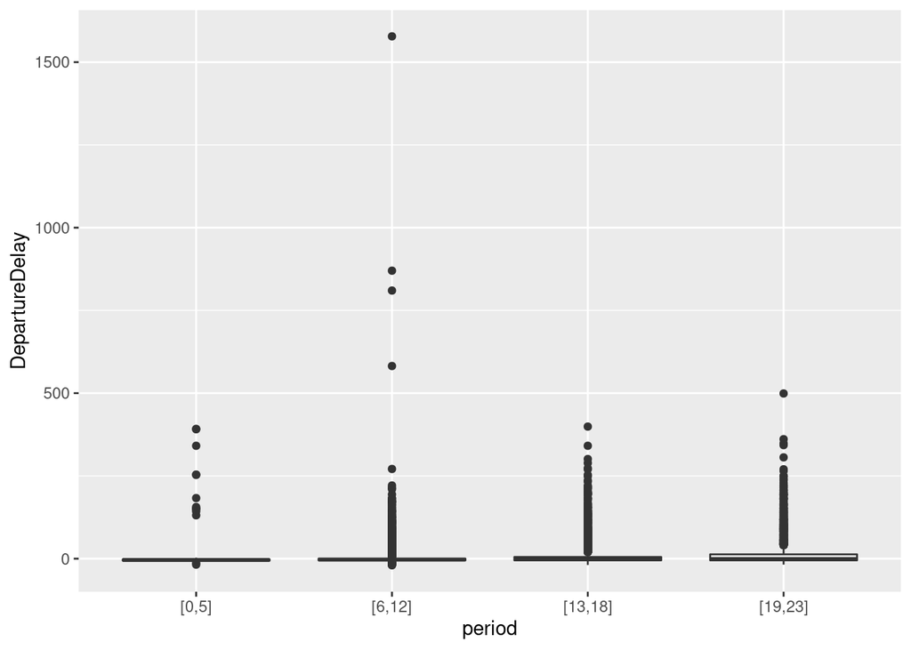

```r
g <- ggplot(flights)

g +
  geom_boxplot(aes(x= period, y=DepartureDelay))
```

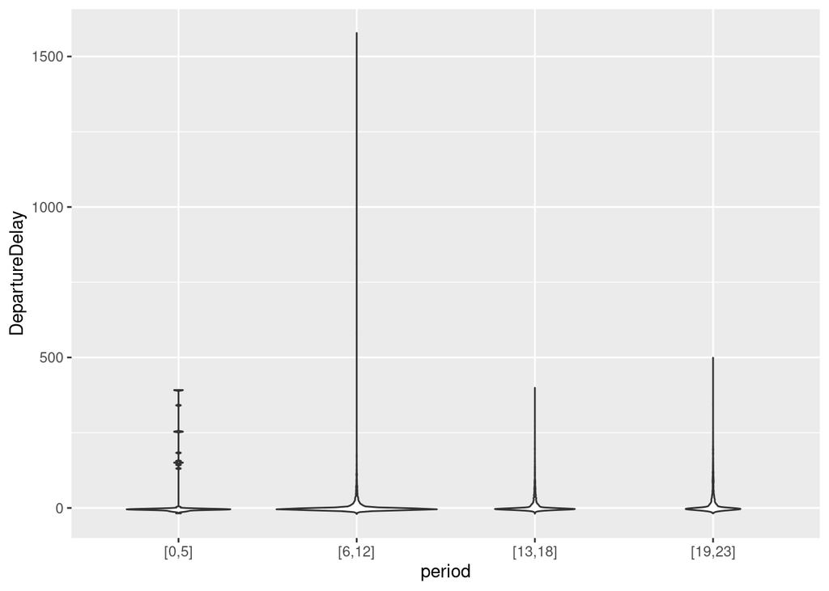

```r
g +
  geom_violin(aes(x= period, y=DepartureDelay))
```

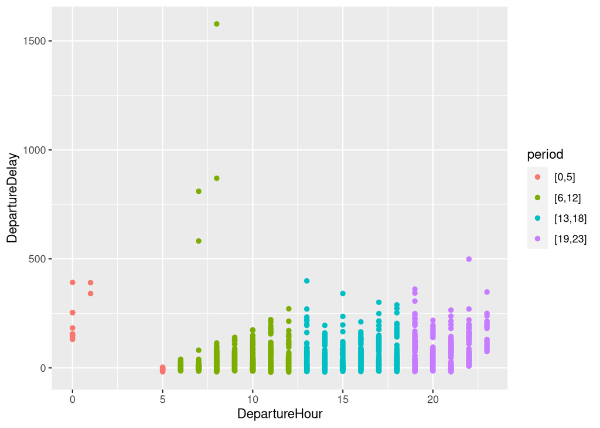

```r
g +
  geom_point(aes(x=DepartureHour, y=DepartureDelay, colour=period))
```

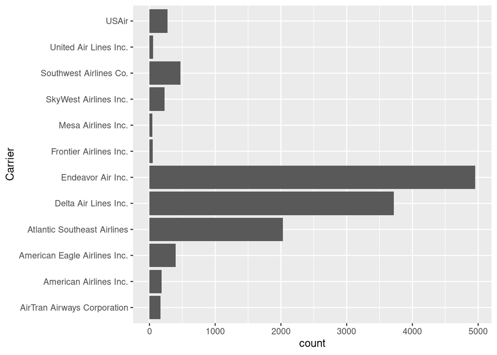

```r
  ggplot(flights) + geom_bar(aes(x=Carrier)) +
  coord_flip()
```

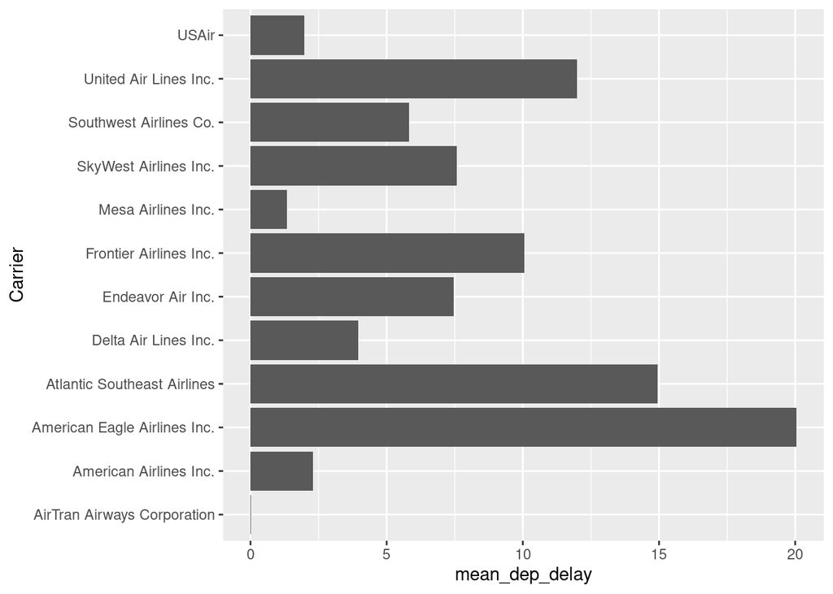

```r
flights %>%
  group_by(Carrier) %>%
  summarize(mean_dep_delay = mean(DepartureDelay, na.rm = TRUE)) %>%
  ggplot() + geom_bar(aes(x=mean_dep_delay, y=Carrier), stat = 'identity')
```

**HACKER EXTRA CREDIT** In either bar chart, figure out how to sort the bars so that the largest bar is the first one, the second largest bar is the second one, and so on.

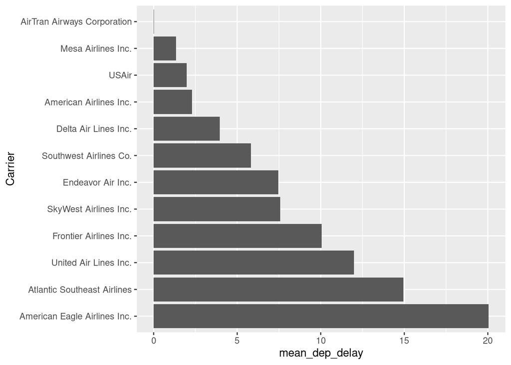

```r
flights %>%
  group_by(Carrier) %>%
  summarize(mean_dep_delay = mean(DepartureDelay, na.rm = TRUE)) %>%
  ggplot() + geom_bar(aes(reorder(Carrier,-mean_dep_delay), y=mean_dep_delay), stat = 'identity') +
  xlab("Carrier") +
  coord_flip()
```

### Task 7: Save flights to an .Rdata file

Since you’ve added some new fields to `flights` save it to an Rdata file that goes inside of the `data` subfolder. You’ll be submitting this file. Name it flights_*yourlastname*.rdata.

```r
saveRDS(flights, file = "data/flights_ogbeborevans.RData")
```

## Deliverables for this problem

Make sure you knit your Rmd file. IMPORTANT: You might notice that there’s a file with the same base name as your file and with a .nb.html extension. The “nb” stands for “notebook” and that file is created on the fly as you are working in your notebook. DO NOT SUBMIT THAT FILE. YOU MUST DO A “knit to html” from the toolbar which will generate a file with just the .html extension. As discussed earlier, if you have errors, your document won’t knit. Comment out error lines and put a comment in saying that you couldn’t get the code chunk to work. After your file is knitted into an html file, simply create a compressed archive (either tar.gz or .zip) of your project folder and upload the compressed archive file into Moodle.